# BIOS0003 Field Work (conducted on 2026-10-07)

## 1 Code setup

*I use something like this in all Rmd files*

```r
library(tidyverse)
library(ggplot2)
library(gtools)

# Set global figure dimensions (e.g., 8 inches wide by 5 inches high)
knitr::opts_chunk$set(
  fig.width = 4,
  fig.height = 4,
  fig.align = "center" # Automatically centers all plots in the preview
)

options(tinytable_html_mathjax = TRUE)
theme_set(theme_minimal(base_size = 14, base_family = "Helvetica"))
```

## 2 Data Cleaning and Prep

To clean and prepare the data I took the following steps:

1. I took the list from the list Maddy created in this [google doc](https://docs.google.com/document/d/1ayEZ5W-id2mDLf8K16_WwtTJwzxPaptZ_ai-xaE0v5s/edit?tab=t.0) and added it to this [google sheet](https://docs.google.com/spreadsheets/d/1wY-feIpz5OgWtJsYgT1v5Mk01S2WGyqa1xK2fIkk68g/edit?gid=0#gid=0).
2. I then munged the data so that there was complete data for the following columns:
   1. Habitat
   2. Habitat grid number (taken from the diagram we have)
   3. Square type (either Small or Large)
   4. Species (the observed Species)
3. I then worked to identify species that had the same name but spelt differently and identified the following:
   1. Grass and Grasses - both changed to Grass
   2. Hook lobed dandelions and Hooked lobed dandelions - both changed to Hook lobed dandelions
   3. Wild cherry and Wild cherry tree - both changed to Wild cherry
4. Assigned an Overall Grid Number (from 1 to 8) to each grid

The output is stored here

*./data/in/field_work_data_cleaned.csv*

Now we can load the data into a dataframe

```r
df = read_csv("../data/in/field_work_data_cleaned.csv", show_col_types = FALSE)
df
```

| habitat | habitat_grid_number | overall_grid_number | square_type | Species |
| --- | --- | --- | --- | --- |
| Wetland | 6 | 1 | small | Common reed |
| Wetland | 6 | 1 | small | Puccinia convovuli |
| Wetland | 6 | 1 | large | Common reed |
| Wetland | 6 | 1 | large | Puccinia convovuli |
| Wetland | 6 | 1 | large | Hedge bindweek |
| Wetland | 6 | 1 | large | Himalayan balsam |
| Wetland | 6 | 1 | large | Xylaria hypoxyion |
| Wetland | 6 | 1 | large | Stinging nettles |
| Woodland | 16 | 2 | small | Common reed |
| Woodland | 16 | 2 | large | Common reed |

[output cut: 55 more lines]

## 3.1 Overall Species Accumulation Curve

> First, lets do this manually

we are going to need a data frame to hold the species accumulation data:

```r
df_accum <- tibble(
  survey_unit = c(0:8), # start at 0 and 8 sample units, overall_grid_number
  species_accum = rep(0, 9) # set species accumulation to 0 to start
)
df_accum
```

| survey_unit | species_accum |
| --- | --- |
| 0 | 0 |
| 1 | 0 |
| 2 | 0 |
| 3 | 0 |
| 4 | 0 |
| 5 | 0 |
| 6 | 0 |
| 7 | 0 |
| 8 | 0 |

We also need a list to hold the species we have seen in total, well work through the sample units adding new species to this list and updating the species_accum in the dataframe above.

```r
species_all = c()
```

Lets do the first sample unit (overall_grid_number = 1) manually…

```r
# Pull a distinct list of species seen in ogn 1
species_ogn <- df |>
  filter(overall_grid_number == 1) |>
  distinct(Species) |>
  pull(Species)

# Add only new ones to the species_all vector
species_all = union(species_all, species_ogn)

# Count how many species we have all together
species_count = length(species_all)

# Update the df_accum data table for ogn = 1
# Note: we're using 1 + 1 here as we started at 0
df_accum$species_accum[1 + 1] <- species_count

df_accum
```

| survey_unit | species_accum |
| --- | --- |
| 0 | 0 |
| 1 | 6 |
| 2 | 0 |
| 3 | 0 |
| 4 | 0 |
| 5 | 0 |
| 6 | 0 |
| 7 | 0 |
| 8 | 0 |

Now we have done that once, lets loop through the rest of the sample units and fill up the data frame:

```r
# Loop through the remaing ogn's from 2 to 8
for (ogn in 2:8) {
  # Then just do the same as we did for ogn = 1
  species_ogn <- df |>
    filter(overall_grid_number == ogn) |>
    distinct(Species) |>
    pull(Species)

  # Add only new ones to the species_all vector
  species_all = union(species_all, species_ogn)

  # Count how many species we have all together
  species_count = length(species_all)

  # Update the df_accum data table for ogn = 1
  df_accum$species_accum[ogn + 1] <- species_count
}

df_accum
```

| survey_unit | species_accum |
| --- | --- |
| 0 | 0 |
| 1 | 6 |
| 2 | 12 |
| 3 | 17 |
| 4 | 23 |
| 5 | 28 |
| 6 | 30 |
| 7 | 33 |
| 8 | 34 |

And now let’s plot this curve:

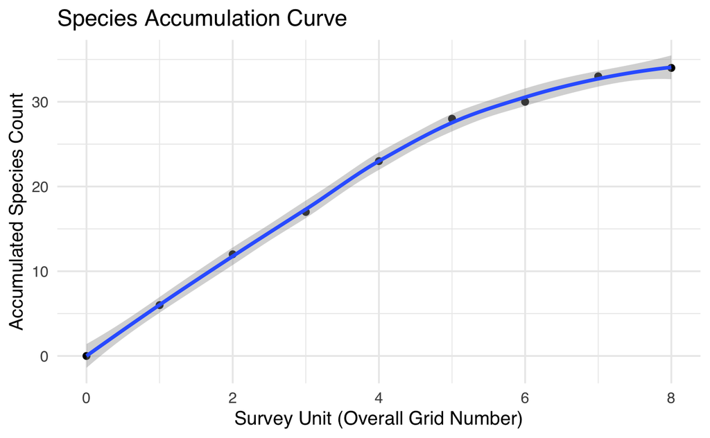

```r
df_accum |>
  ggplot(mapping = aes(x = survey_unit, y = species_accum)) +
    geom_point() +
    stat_smooth(method = "loess", formula = "y ~ x") +
    labs(
      title = "Species Accumulation Curve",
      x = "Survey Unit (Overall Grid Number)",
      y = "Accumulated Species Count"
    )
```

**!!Boom, we have our first species accumulation curve!!**

## 3.2 But wait … what if we change the order of sample units?

Will it affect the graph if instead of adding the species observations from the sample units in order (from 1 to 8), we randomise the order in which we add them?

First, lets wrap up our core logic in a function so we can easily reuse it:

```r
process_sample_unit_species <- function(df, ogn, species_all) {
  # Extract the unique species for this ogn
  species_ogn <- df |>
    filter(overall_grid_number == ogn) |>
    distinct(Species) |>
    pull(Species)

  # Add only new ones to the species_all vector
  species_all = union(species_all, species_ogn)

  # Count how many species we have all together
  species_count = length(species_all)

  return(list(
    "species_all" = species_all,
    "species_count" = species_count
  ))
}
```

Now we can easily rerun the analysis but using the numbers 1 through 8 in random order:

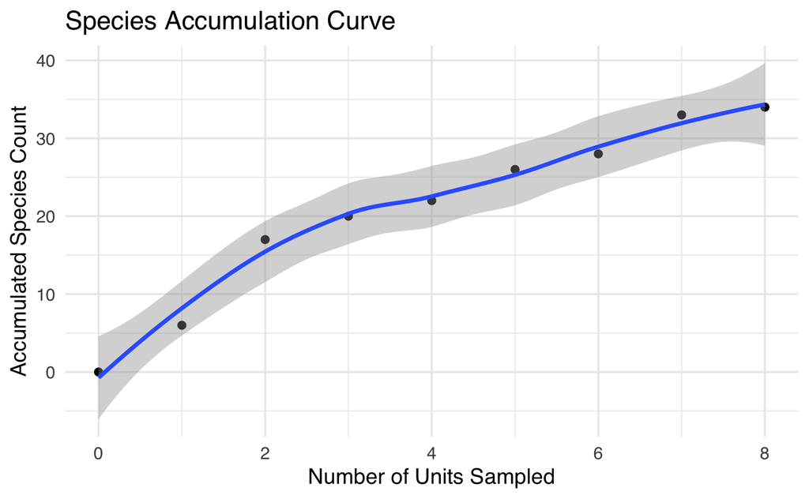

```r
# set up the df to store the data
# NOTE: we're now using just a count of sampled areas: sampled_area_count or sac
df_accum <- tibble(
  sampled_area_count = c(0:8), # now we're not using direct ogn we're using sac
  species_accum = rep(0, 9) # set species accumulation to 0 to start
)
species_all = c()

set.seed(42)

sac = 1
for (ogn in sample(seq(1, 8), 8)) {
  accum_data <- process_sample_unit_species(
    df = df,
    ogn = ogn,
    species_all = species_all)

  species_all <- accum_data$species_all
  species_count <- accum_data$species_count

  # Update the df_accum data table WITH THE SAC, not the ogn
  df_accum$species_accum[sac + 1] <- species_count

  sac <- sac + 1
}
df_accum |>
  ggplot(mapping = aes(x = sampled_area_count, y = species_accum)) +
    geom_point() +
    stat_smooth(method = "loess", formula = "y ~ x") +
    labs(
      title = "Species Accumulation Curve",
      x = "Number of Units Sampled",
      y = "Accumulated Species Count"
    )
```

**!!WOW that looks pretty different!!**

## 3.3 Calculating all possible combinations

So if the order in which we process the sample units matter, we should really look at all possible permutations.

We can use the permutations function from the gtools library to help here … but …

first we should wrap up our code from the last cell so that we can look over it for each permutation.

```r
process_sameple_area_permutation <- function(area_permutation, permutation_id) {
  # a df to hold the data for this permutation
  df_accum <- tibble(
    permutation_id = rep(permutation_id, 9), # so we can differentiate perms
    sampled_area_count = c(0:8),
    species_accum = rep(0, 9)
  )

  # Variables for each run
  species_all = c()
  sac = 1

  # Perform the loop for this permutation
  for (ogn in area_permutation) {
    accum_data <- process_sample_unit_species(
      df = df,
      ogn = ogn,
      species_all = species_all)

    species_all <- accum_data$species_all
    species_count <- accum_data$species_count

    # Update the df_accum data table with the sac
    df_accum$species_accum[sac + 1] <- species_count

    sac <- sac + 1
  }

  # Return the de_accum for this permutation
  return(df_accum)
}
```

Now we have that locked down we can create the permutations matrix to hold everything and run the full simulations

```r
# If we don't limit this, it will be 40320!
number_of_perms_required = 1e4

all_perms <- permutations(n = 8, r = 8, v = 1:8)

# set.seed(123) # Optional: ensures reproducibility
random_indices <- sample(nrow(all_perms), size = number_of_perms_required)

# 3. Subset the matrix
sampled_perms <- all_perms[random_indices, ]

df_perms <- tibble(
  perm = sampled_perms,
  perm_id = 1:length(sampled_perms[,1])
)

df_accum <- df_perms |>
  rowwise() |>
  reframe(process_sameple_area_permutation(perm, perm_id))
```

Now we have done the Monte Carlo simulations, we can graph it out

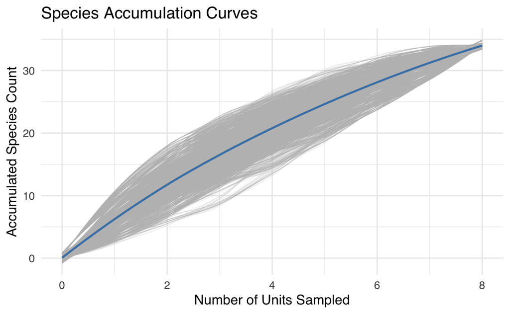

```r
df_accum |>
  ggplot(mapping = aes(x = sampled_area_count)) +
    geom_smooth(
      aes(y = species_accum, group = permutation_id),
      method = "loess",
      formula = y ~ x,
      se = FALSE,
      alpha = 0.1,
      colour = "grey",
      linewidth = 0.01) +
    geom_smooth(
      aes(y = species_accum),
      method = "loess",
      formula = y ~ x,
      se = FALSE,
      alpha = 0.1,
      colour = "steelblue",
      linewidth = 1
    ) +
    labs(
      title = "Species Accumulation Curves",
      x = "Number of Units Sampled",
      y = "Accumulated Species Count"
    )
```

**Now that’s cool**

## 4 We can also look at the correlations between sample unit and species

Lets pivot the data to get a matrix of presence and absense

```r
df_presence <- df |>
  distinct(habitat, Species) |>
  mutate(presence = 1) |>
  complete(habitat, Species, fill = list(presence = 0)) |>
  mutate(
    # Sort Species on y-axis: least overall abundance at bottom, most at top
    Species = fct_reorder(Species, presence, sum, .desc = TRUE),

    # Sort Habitat on x-axis: most biodiversity on left, least on right
    habitat = fct_reorder(habitat, presence, sum, .desc = TRUE),

    # Convert present to factor for plotting
    presence = factor(presence)
  )

df_presence
```

| habitat | Species | presence |
| --- | --- | --- |
| Built | Brambles | 1 |
| Built | Bristly oxtongue | 1 |
| Built | Bull wistly | 1 |
| Built | Cherry plum | 0 |
| Built | Common reed | 0 |
| Built | Dandelion weed | 0 |
| Built | Dried plants | 0 |
| Built | Golovinomyces sordidus | 0 |
| Built | Grass | 1 |
| Built | Great stinging nettles | 0 |

[output cut: 160 more lines]

[figure not shown]

```r
ggplot(
  df_presence,
  aes(x = habitat, y = Species, fill = presence)
) +
  geom_tile(color = "white", linewidth = 0.5) +
  scale_fill_manual(
    values = c("0" = "whitesmoke", "1" = "forestgreen"),
    labels = c("Absent (0)", "Present (1)"),
    name = "Status"
  ) +
  theme_minimal() +
  theme(
    axis.text.x = element_text(angle = 45, hjust = 1, face = "italic"),
    axis.text.y = element_text(size = 5)
  ) +
  labs(
    title = "Species Presence/Absence Across Habitats",
    x = "Species",
    y = "Habitat"
  )
```